# Emily Mikucki’s BIO 381 Homepage

Emily Mikucki’s BIO 381 Homepage

### About Me

I am a second-year PhD student in Biology studying the physiological consequences of increased warming in diapausing *Pieris rapae* butterflies. I am co-advised by Dr. Brent Lockwood and Dr. Alison Brody.

[UVM Biology Graduate Student Page](http://www.uvm.edu/~biology/?Page=students/mikucki.php&SM=facultysubmenu.html)

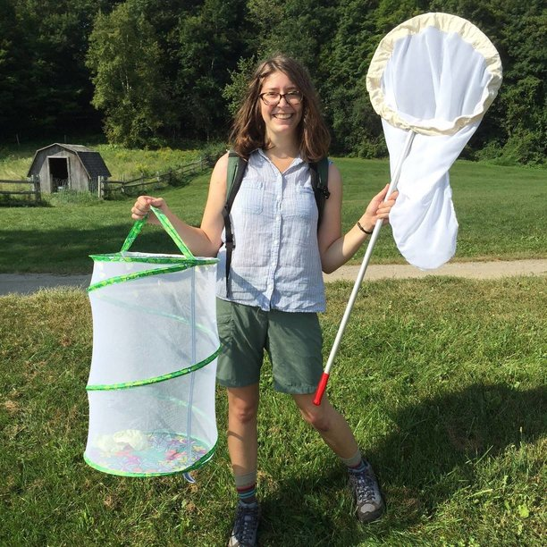

Collecting butterflies at Shelburne Farms in Shelburne, VT

## Computational Biology - Spring 2017

## Assignments:

- Assignment 1
- Assignment 2
- **Assignment 3**
  - Hypotheses Flowchart (don’t forget to slide!)
  - Original Powerpoint
  - Beamer Slides (.Rmd)
  - Beamer Slides (PDF)
- **Assignment 4**
  - Sample Data: Transform .csv to .Rmd
  - Working with Regular Expressions
- Assignment 5
- Assignment 6 & 7
- Assignment 8
- Assignment 9
- Assignment 10

## Notes:

#### Lecture

- January 17, 2017: Course Introduction
- January 24, 2017: Working with RStudio
- January 26, 2017: Working with RStudio Cont.
- January 31, 2017: Typora and Beamer Slides
- February 2, 2017: Creating and Importing Data
- February 7, 2017: Regular Expressions
- February 9, 2017: Regular Expressions Cont.
- February 14, 2017: Data Structures in R
- February 16, 2017: Data Structures in R Cont.
- February 21, 2017: Subsetting in R
- February 23 & 28, 2017: Probability Distributions
- March 2, 2017: Working with R Functions
- March 9-28, 2017: Illustration of structured programming
- March 21, 2017: Brandon Ogbunu Guest Lecture
- March 28, 2017: Control Structures for R Programming
- March 30, 1017: For Loops
- April 6, 2017: More For Loops
- April 11, 2017: Randomization Tests
- April 13, 2017: Markov Models
- April 18, 2017: Markov Models Cont.
- April 20, 2017: The Apply Function
- April 25, 2017: Basic Graphics in R

#### Lab

- January 18, 2017: Creating a Repository
- April 12, 2017: Spatial Analysis
- April 19 - May 3, 2017: R Presentations

## Demos:

- January 24, 2017: RMarkdown Demo (Updated 01/26/2017)
- January 26, 2017: First R Script
- January 31, 2017: Typora Demo
- January 31, 2017: Beamer Slides Demo
- February 14, 2017: Data Structures in R

## Presentations

- R Package Presentation: Animation
- Research Presentation: Physiological consequences and evolutionary history of diapause strategies in butterflies